# Approximately Exact Calculations for LMM

April 15, 2015

## Where we're going

A method to evaluate the likelihood or posterior for a linear mixed model in order to

1. **Profile** the shape of the function for sensible inference
2. **Estimate** parameters

while being sure that we're not missing the global optimum.

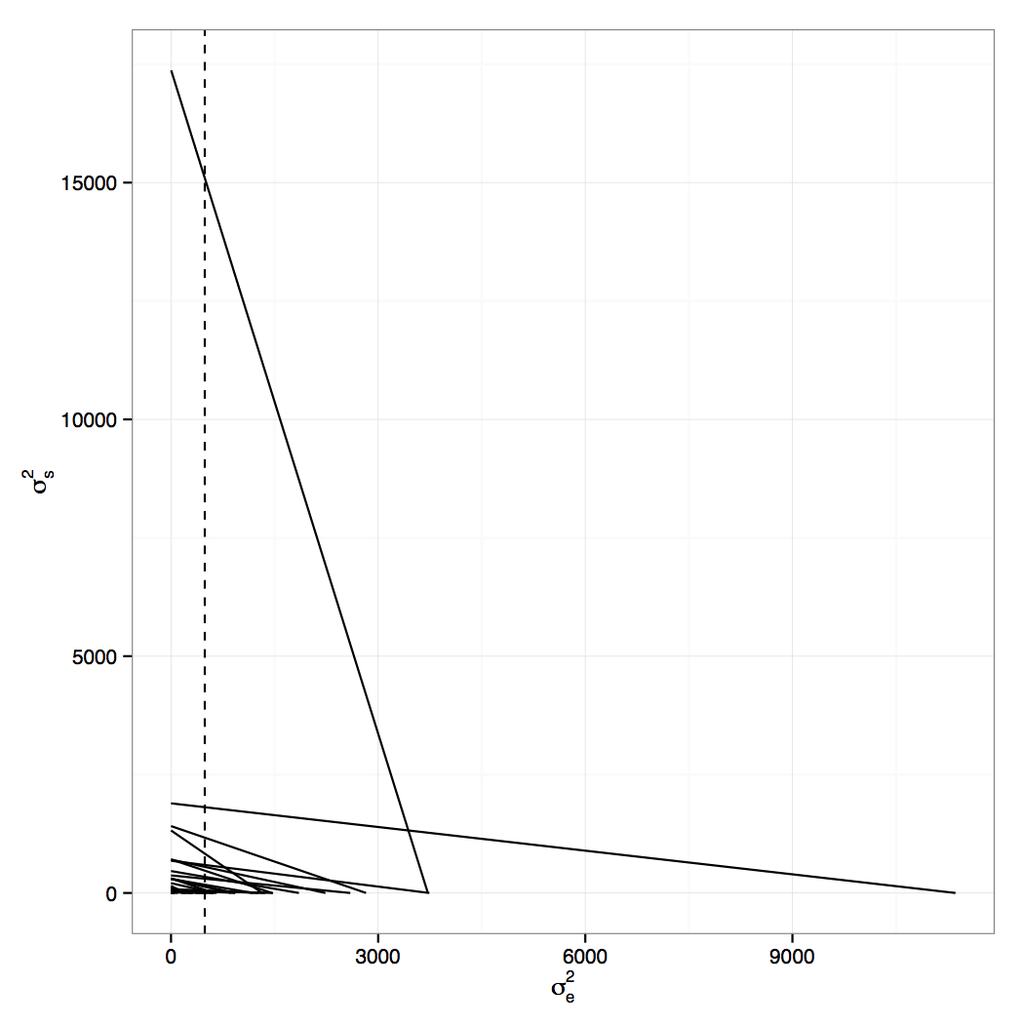

## Genesis

[figure not shown]

*Approximately Exact Calculations for Linear Mixed Models*, Lavine and Hodges, 2015.

## Linear Mixed Models

\[ y = X \beta + Z u + \epsilon \]

- \(y\): vector of \(n\) observations
- \(X\): known \(n \times p\) matrix
- \(\beta\): vector of \(p\) unknown fixed effects coefs
- \(Z\): \(n \times q\) matrix
- \(u\): vector of \(q\) unknown random effects coefs
- \(\epsilon\): vector of \(n\) errors

\[ \epsilon \sim \textrm{N}(0, R); \quad u \sim \textrm{N}(0, G) \]

## Traditional estimation

1. Integrate out the fixed effects, maximize the restricted likelihood (\(RL\)) to estimate \(G\) and \(R\).
2. Treat \(G\), \(R\) as known. Plug into ML estimate for \(\beta\) and \(u\).

Main burden of calculation: optimize the **restricted likelihood**.

## Existing Methods in `lmer, nlme`

[figure not shown]

- BOBYQA: quadratic approximation
- Nelder-Mead: iterative simplex
- BFGS: quasi-Newton
- **Pros**: works for any \(f\), derivative-free, fast
- **Cons**: may not converge, can miss global optima

## The Re-expression

Two variance model:

\[ \epsilon \sim \textrm{N}(0, \sigma^2_e \Sigma_e); \quad u \sim \textrm{N}(0, \sigma^2_s \Sigma_s) \]

A more tractable objective function:

\[ \log \pi (\sigma^2_e, \sigma^2_s) \propto \sum_j \left[ c_j \log (a_j \sigma^2_s + b_j \sigma^2_e ) + \frac{d_j}{a_j \sigma^2_s + b_j \sigma^2_e} \right] \]

\[ \{a_j, b_j, c_j, d_j\} > 0 \]

## Groundwork

## Objectives

Develop a method to evaluate \(f(\sigma^2_e, \sigma^2_s)\) in order to

1. **Profile** the shape of the function for sensible inference
2. **Estimate** parameters

\[ f(\sigma^2_e, \sigma^2_s) \propto \sum_j \left[ c_j \log (a_j \sigma^2_s + b_j \sigma^2_e ) + \frac{d_j}{a_j \sigma^2_s + b_j \sigma^2_e} \right] \]

## Exploiting the Linear structure

\[ c_j \log(\textrm{linear term}) + \frac{d_j}{\textrm{linear term}} \]

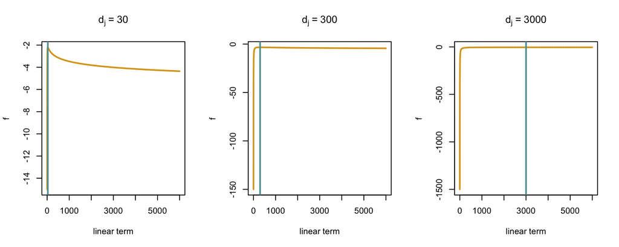

## Exploiting the Linear structure

\[ f(\sigma^2_e, \sigma^2_s) \propto \sum_j \left[ c_j \log (a_j \sigma^2_s + b_j \sigma^2_e ) + \frac{d_j}{(a_j \sigma^2_s + b_j \sigma^2_e)} \right] \]

\[ \frac{\partial f(\sigma^2_e, \sigma^2_s)}{\partial \sigma^2_e} \propto \sum_j \frac{a_j (a_j c_j \sigma^2_s + b_j c_j \sigma^2_e - d_j)}{(a_j \sigma^2_s + b_j \sigma^2_e)^2} \]

\[ \begin{aligned} 0 &= a_j c_j \sigma^2_s + b_j c_j \sigma^2_e - d_j \\ \\ \sigma^2_s &= \frac{d_j}{a_j c_j} - \frac{b_j}{a_j}\sigma^2_e \end{aligned} \]

## Contribution of one term

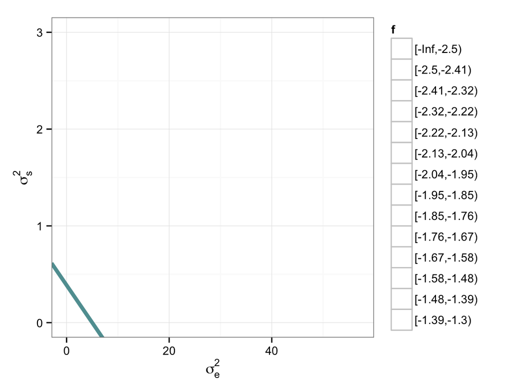

\(a_j = 12.9; \quad b_j = 1; \quad c_j = 1; \quad d_j = 5\)

\(f\) is maxed along \(\sigma^2_s = \frac{d_j}{a_j c_j} - \frac{b_j}{a_j}\sigma^2_e\)

## Contribution of one term

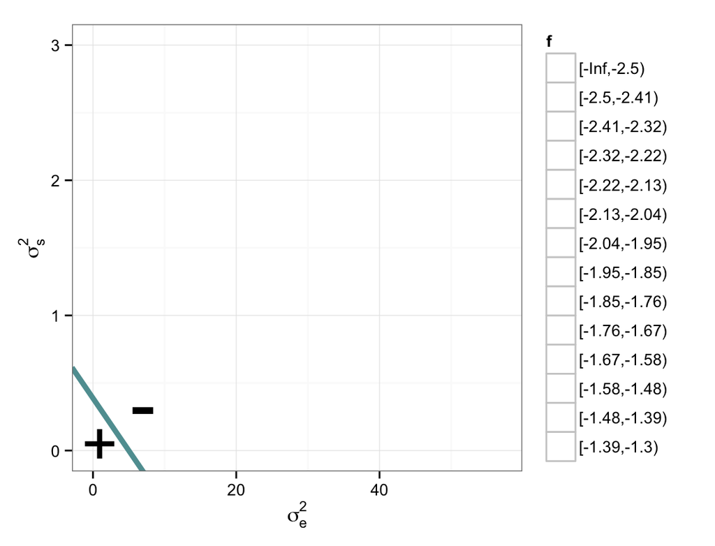

## Contribution of one term

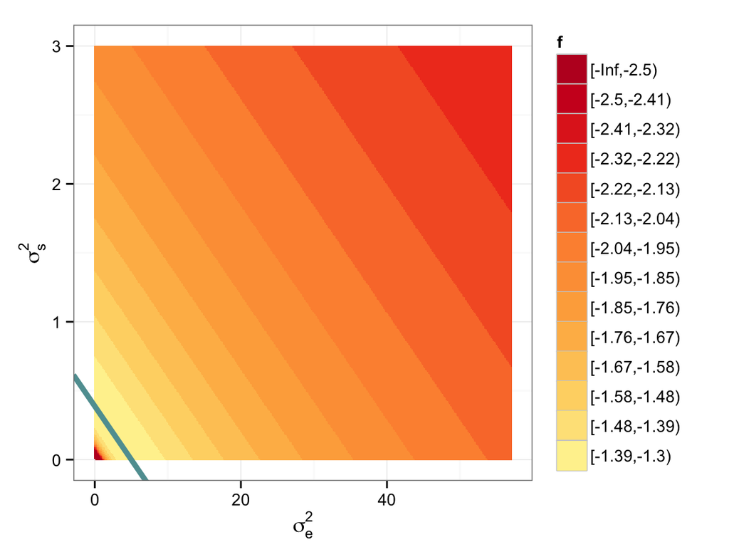

## Box above line

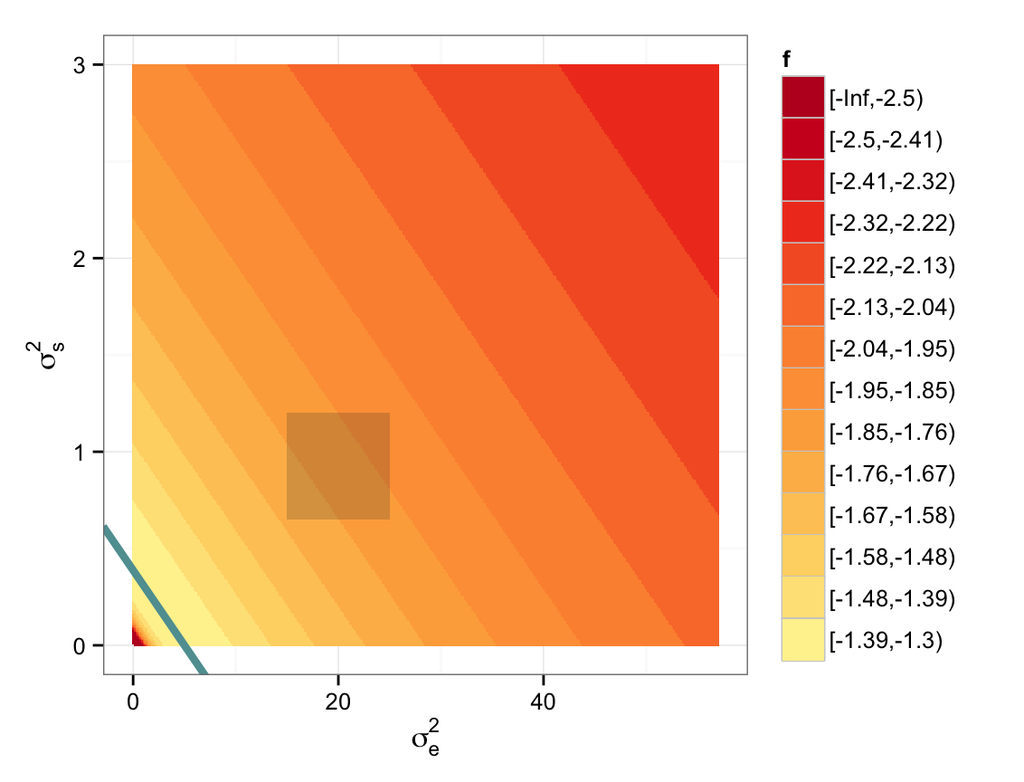

## Box above line

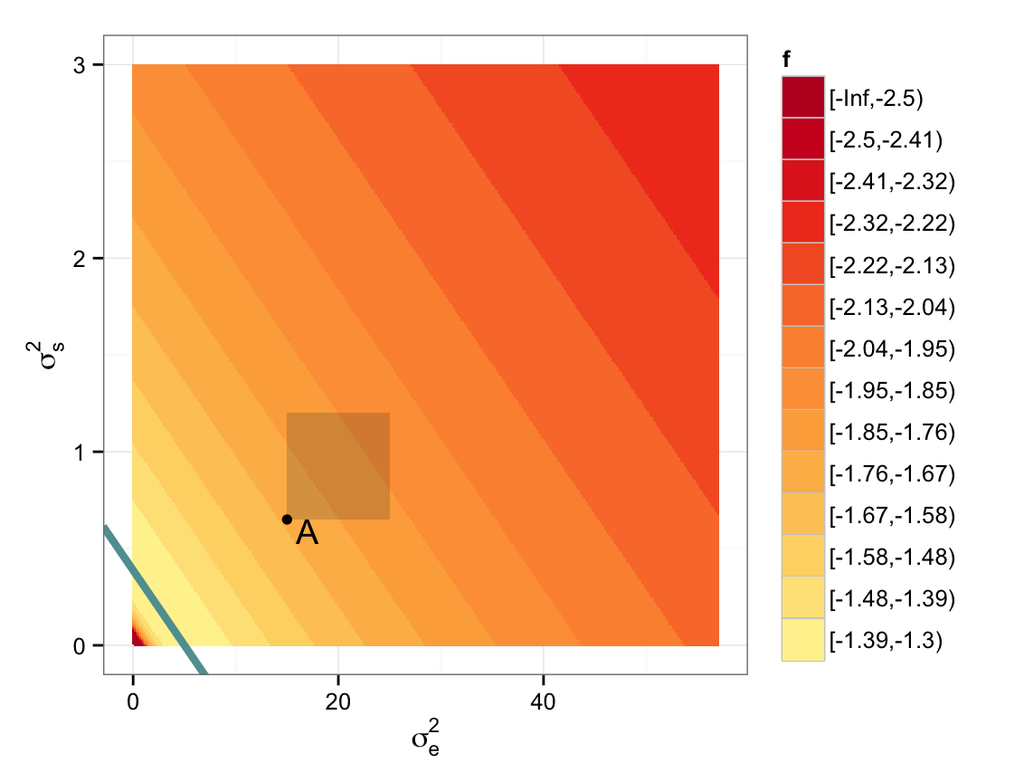

## Box above line

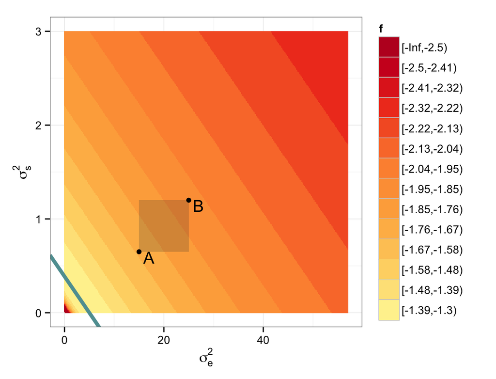

Bounds on \(f\) in box \(b_a: \left(f(B), f(A) \right)\)

## Box straddles line

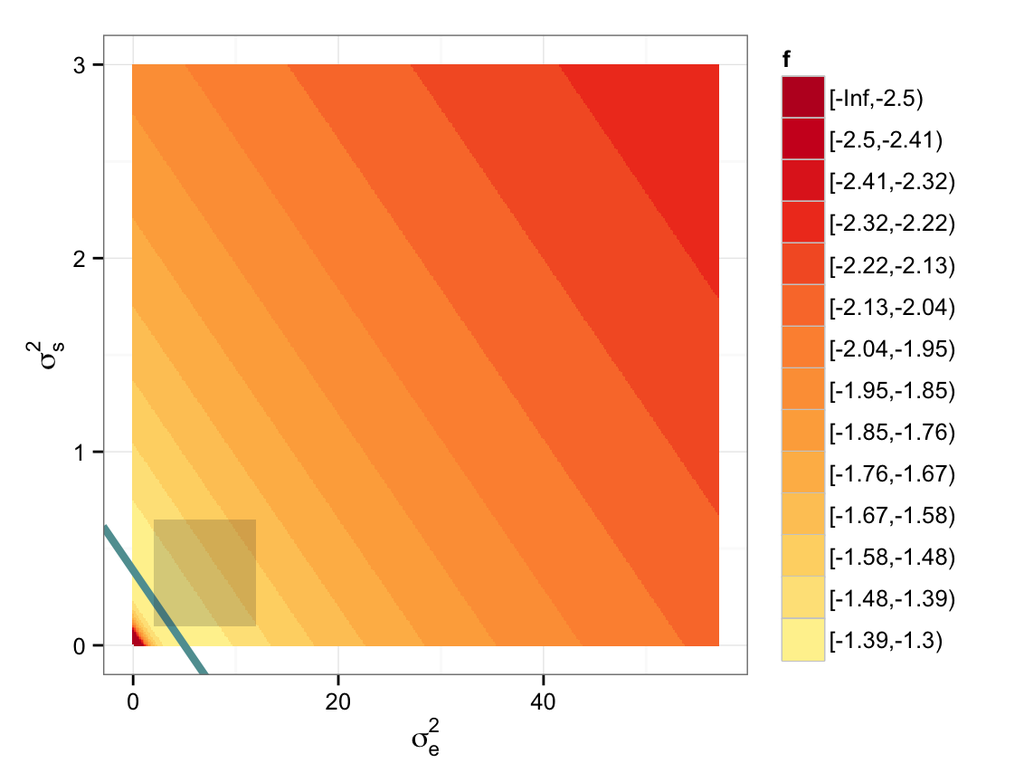

## Box straddles line

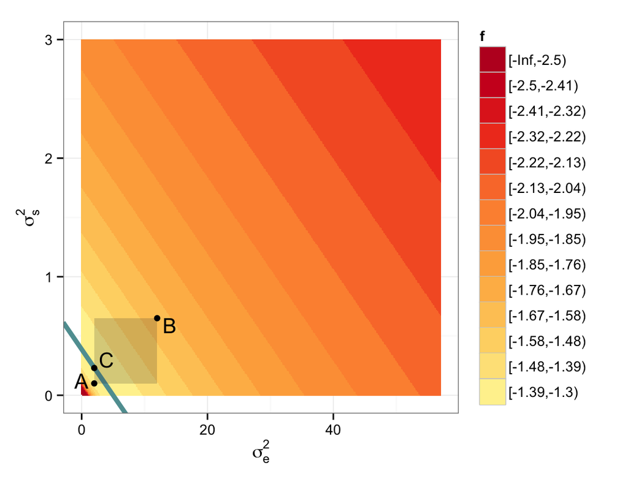

Bounds on \(f\) in box \(b_s: \left(min\left(f(A), f(B)\right), f(C) \right)\)

## Branch for more precision

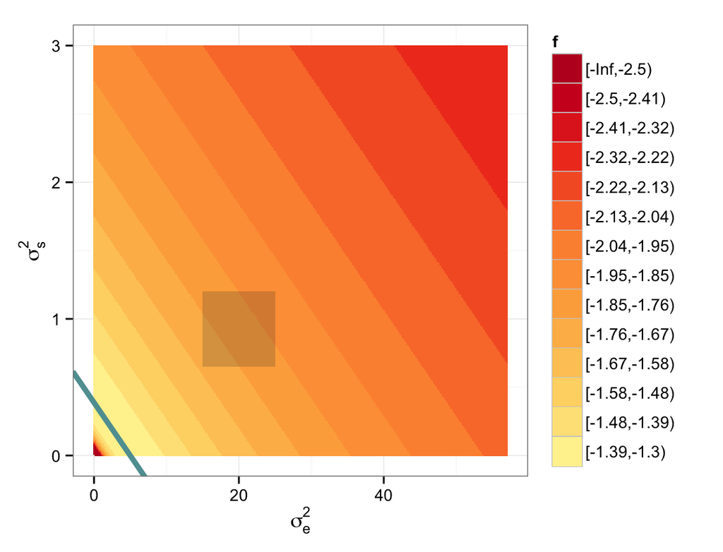

## Branch for more precision

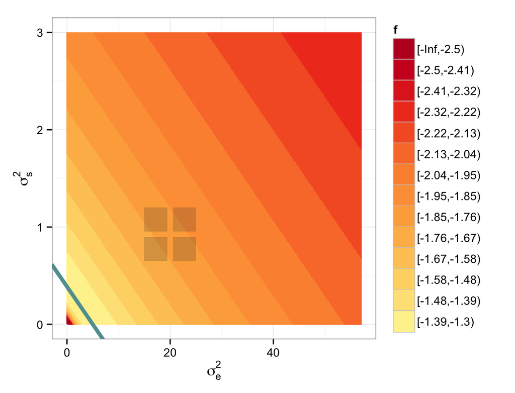

## Branch for more precision

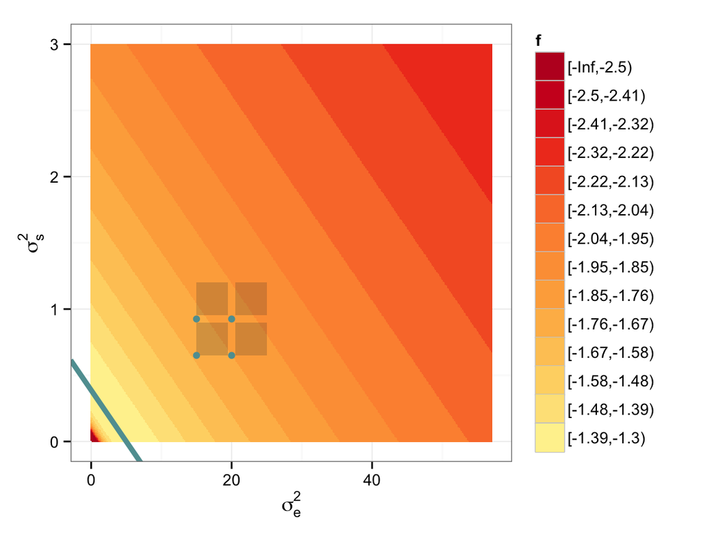

## Branch for more precision

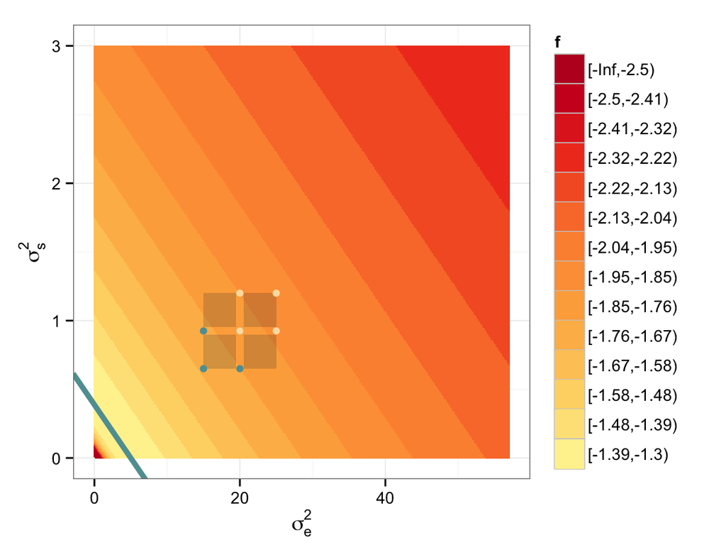

## Observations from one term

- Each term is maximized along a line in Q1.
- Slope < 0 and intercept > 0.
- Within \(b\) the top-right and bottom-left form the bounds.
  - above the line, \(\left(f(TR), f(BL)\right)\)
  - below the line, \(\left(f(BL), f(TR)\right)\)
  - straddle the line, \(\left(min(f(TR), f(BL)), f(line)\right)\)
- For narrower bounds, subdivide \(b\) (branch).

## Contribution of two terms

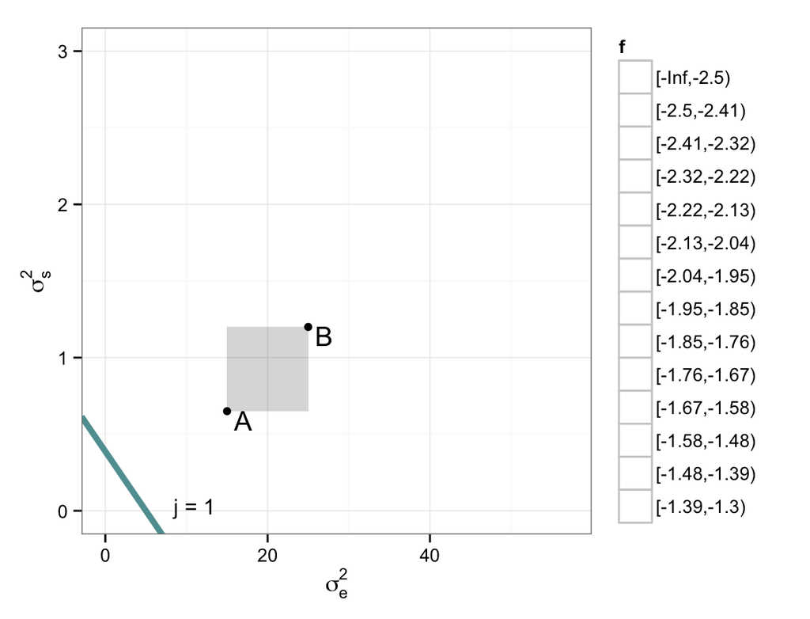

\[ j = 1; \quad \left(f_1(B), f_1(A) \right) \]

## Contribution of two terms

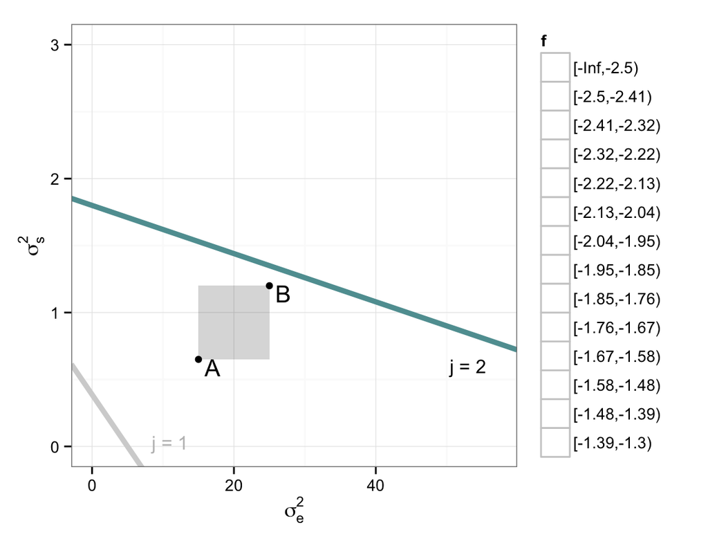

\[ j = 1; \quad \left(f_1(B), f_1(A) \right) \\ j = 2; \quad \left(f_2(A), f_2(B) \right) \]

## Contribution of two terms

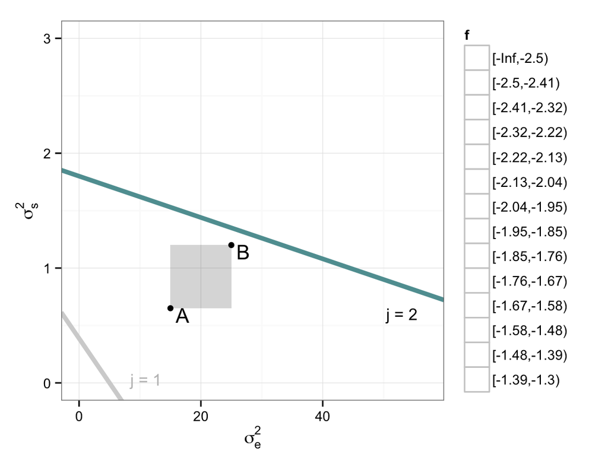

\[ \left.\begin{aligned} j &= 1; \quad \left(f_1(B), f_1(A) \right)\\ j &= 2; \quad \left(f_2(A), f_2(B) \right) \end{aligned} \right\} \qquad \underbrace{f_1(B) + f_2(A)}_{L^b}, \underbrace{f_1(A) + f_2(B)}_{U^b} \]

## Observations from two terms

Within box \(b\), the bounds on \(f\) can be formed by

\[ L^b \equiv \sum_j L^b_j \\ U^b \equiv \sum_j U^b_j \]

where each term in the sum is \(f_j(p)\) evaluated at the appropriate point \(p\).

Because \(f\) is continuous, \(U^b - L^b \rightarrow 0\) as \(b\) shrinks in both directions.

## An algorithm

To evaluate \(f\) arbitrarily well everywhere within \(B\),

1. Specify \(\epsilon\).
2. With \(y, X, Z\) compute \(\{a_j, b_j, c_j, d_j\}\) for all \(j\).
3. For every active box \(b\)
- evaluate \(f_j(p)\) for all \(j\) to get \(L^b, U^b\)
- if \(U^b - L^b < \epsilon\), make \(b\) inactive
- else subdivide \(b\) into 4 active boxes and repeat (3).

For optimization only:

- make \(b\) inactive if \(U^b << L^{global}\)

## Example

## Health care costs

**Question**: what will be the estimated cost of moving people to HMO plans?

Data on cost of \(i = 1, \ldots, 341\) plans in \(j = 1, \ldots, 45\) states

\[ \begin{aligned} y_{ij} &= \alpha_j + \epsilon_{ij} \\ \alpha_j &= \beta_0 + \beta_1 x_{1j} + \beta_2 x_{2j} + \delta_j \end{aligned} \]

- \(X\): 341 \(\times\) 3 matrix
- \(Z\): 341 \(\times\) 45 matrix

## Terms in the sum

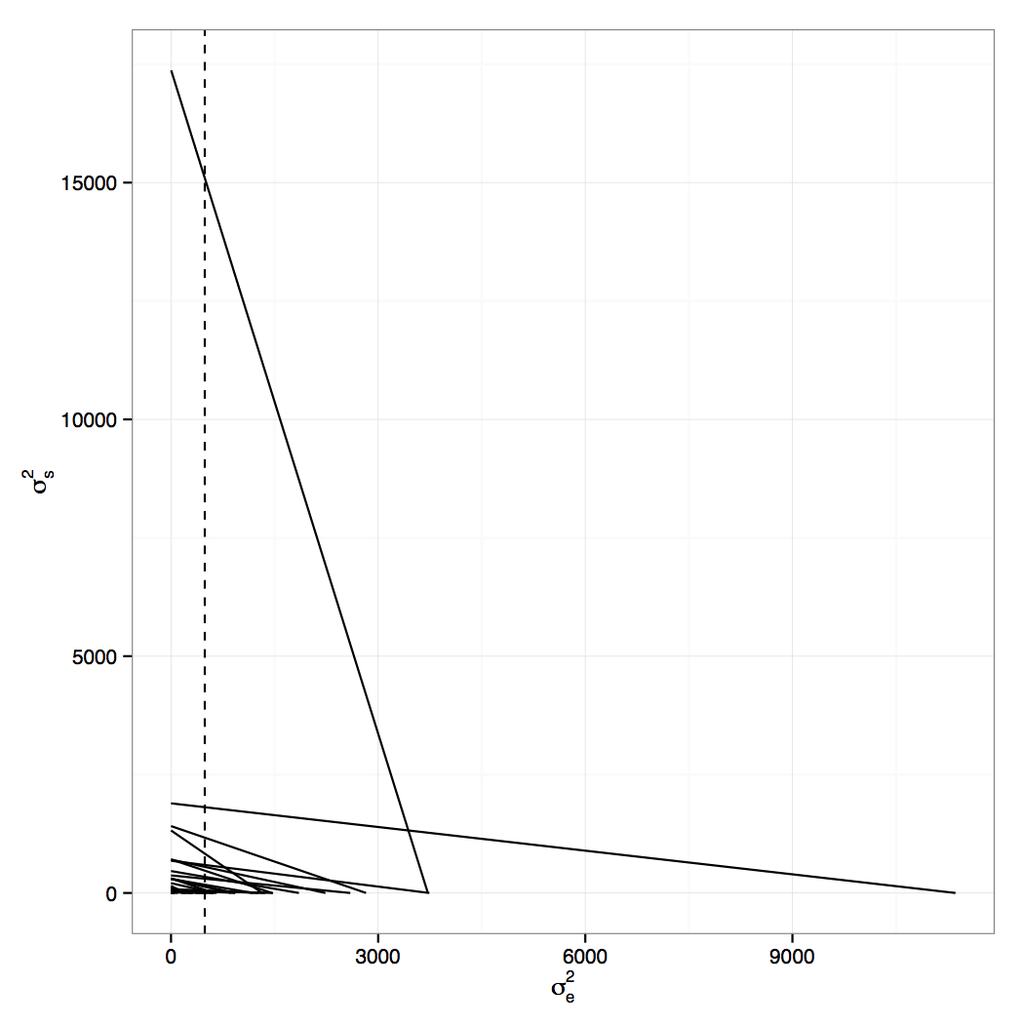

## Partitioning sequence

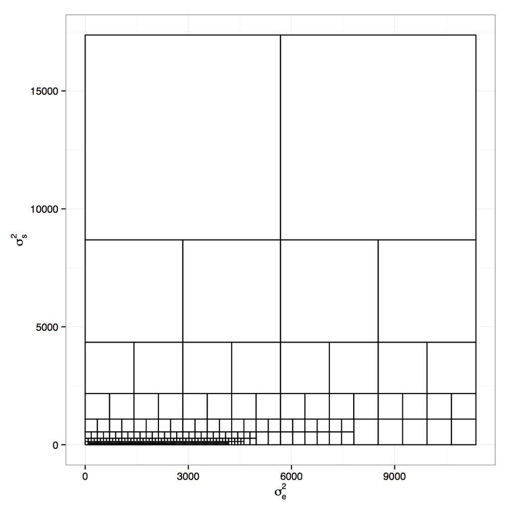

## Restricted LL

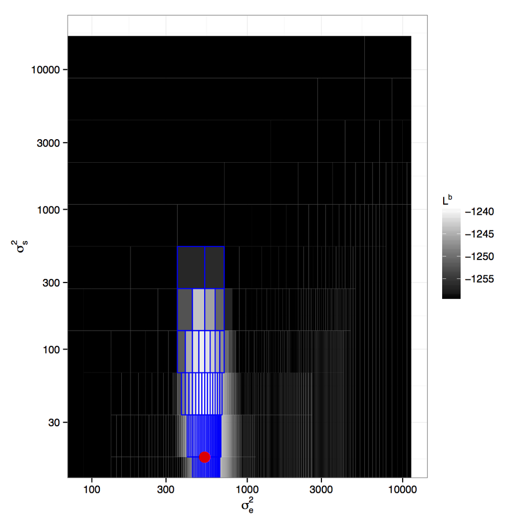